# Week 5 Assignment

Joshua Registe

9/28/2019

# 1 CSV Creation and Import

The airline information data is being imported from a MySQL database. information on username, password and host hidden for security. The following code prints the table required for the assignment.

```r
query1 = "SELECT * from assignment5table"
airline.info<-dbGetQuery(connection,query1)

airline.info
```

```
##   ID Airline Arrival_Status Los Angeles Phoenix San Diego San Francisco
## 1  1  ALASKA        on time         497     221       212           503
## 2  2  ALASKA        delayed          62      12        20           102
## 3  3 AM West        on time         694    4840       383           320
## 4  4 AM West        delayed         117     415        65           129
##   Seattle
## 1    1841
## 2     305
## 3     201
## 4      61
```

# 2 Using tidyr

To properly visualize our information, this data is best represented in a long format and so tidyr is used with the function “gather” in order to achieve this as shown below.

```r
airline.info<-airline.info[c(2:length(airline.info))]
```

```r
airline.info.long<-gather(airline.info,key = "City", value = "Count",-Airline,-Arrival_Status)
airline.info.long
```

```
##    Airline Arrival_Status          City Count
## 1   ALASKA        on time   Los Angeles   497
## 2   ALASKA        delayed   Los Angeles    62
## 3  AM West        on time   Los Angeles   694
## 4  AM West        delayed   Los Angeles   117
## 5   ALASKA        on time       Phoenix   221
## 6   ALASKA        delayed       Phoenix    12
## 7  AM West        on time       Phoenix  4840
## 8  AM West        delayed       Phoenix   415
## 9   ALASKA        on time     San Diego   212
## 10  ALASKA        delayed     San Diego    20
## 11 AM West        on time     San Diego   383
## 12 AM West        delayed     San Diego    65
## 13  ALASKA        on time San Francisco   503
## 14  ALASKA        delayed San Francisco   102
## 15 AM West        on time San Francisco   320
## 16 AM West        delayed San Francisco   129
## 17  ALASKA        on time       Seattle  1841
## 18  ALASKA        delayed       Seattle   305
## 19 AM West        on time       Seattle   201
## 20 AM West        delayed       Seattle    61
```

# 3 Analysis & Conclusions

we can begin to look at this data by simply comparing the airlines and how many of their planes are delayed vs on time.

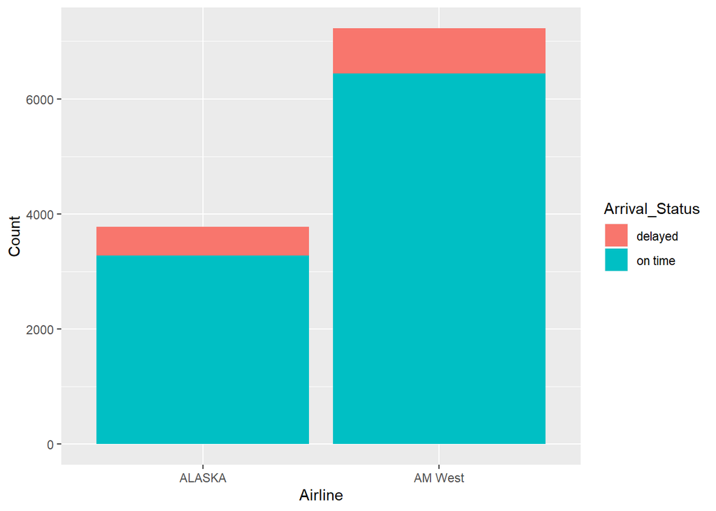

```r
airline.info.long %>%
  ggplot(aes(y = Count, x = Airline))+geom_col(aes(fill = Arrival_Status), position = "stack")
```

According to the figure above, the AM West airline carries many more flights than the Alaska airline. Additionally the proportion of of flights that are delayed by airline seem to be comparable but we will check this with further analysis.

If we break this out by City, we’ll notice that Phoenix, Arizona is the primary source of flights for the AM West airline by a large margin; while Seattle, Washington was the primary source of flights for Alaska airlines.

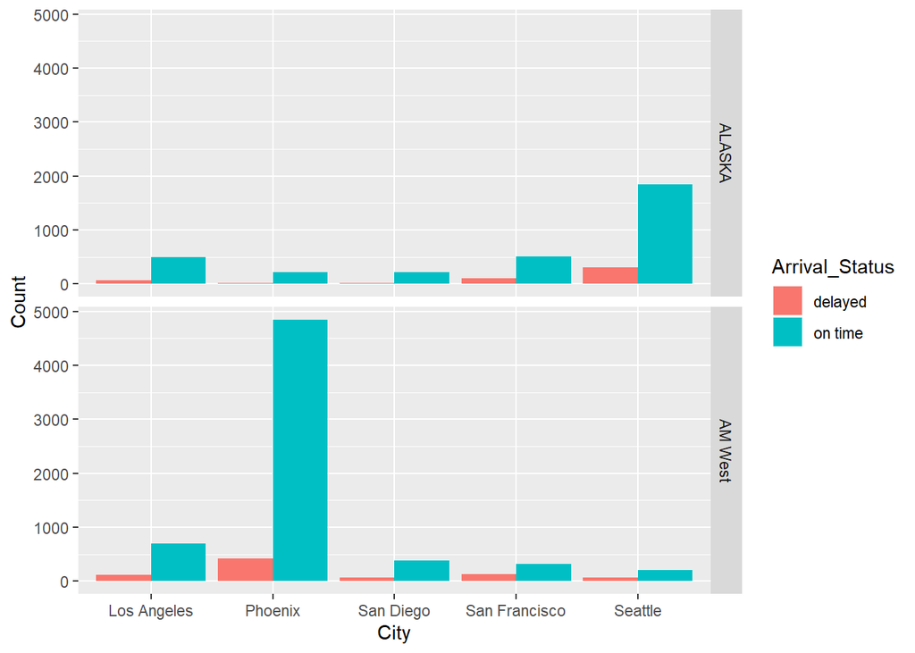

```r
airline.info.long %>%
  ggplot(aes(y = Count, x = City))+geom_col(aes(fill = Arrival_Status), position = "dodge")+facet_grid(Airline~.)
```

To assess which airline has a higher probability of delays, we can use dplyr to group these by city and airline and determine the probability that an airline will have a delay based on this current dataset. the following table shows these probabilities.

```r
 airline.info.long<-airline.info.long%>%
    group_by(Airline,City)%>%mutate(Occurance_Probability= Count/sum(Count))

airline.info.long[c(1,2,3,5)]
```

```
## # A tibble: 20 x 4
## # Groups:   Airline, City [10]
##    Airline Arrival_Status City          Occurance_Probability
##    <chr>   <chr>          <chr>                         <dbl>
##  1 ALASKA  on time        Los Angeles                  0.889
##  2 ALASKA  delayed        Los Angeles                  0.111
##  3 AM West on time        Los Angeles                  0.856
##  4 AM West delayed        Los Angeles                  0.144
##  5 ALASKA  on time        Phoenix                      0.948
##  6 ALASKA  delayed        Phoenix                      0.0515
##  7 AM West on time        Phoenix                      0.921
##  8 AM West delayed        Phoenix                      0.0790
##  9 ALASKA  on time        San Diego                    0.914
## 10 ALASKA  delayed        San Diego                    0.0862
## 11 AM West on time        San Diego                    0.855
## 12 AM West delayed        San Diego                    0.145
## 13 ALASKA  on time        San Francisco                0.831
## 14 ALASKA  delayed        San Francisco                0.169
## 15 AM West on time        San Francisco                0.713
## 16 AM West delayed        San Francisco                0.287
## 17 ALASKA  on time        Seattle                      0.858
## 18 ALASKA  delayed        Seattle                      0.142
## 19 AM West on time        Seattle                      0.767
## 20 AM West delayed        Seattle                      0.233
```

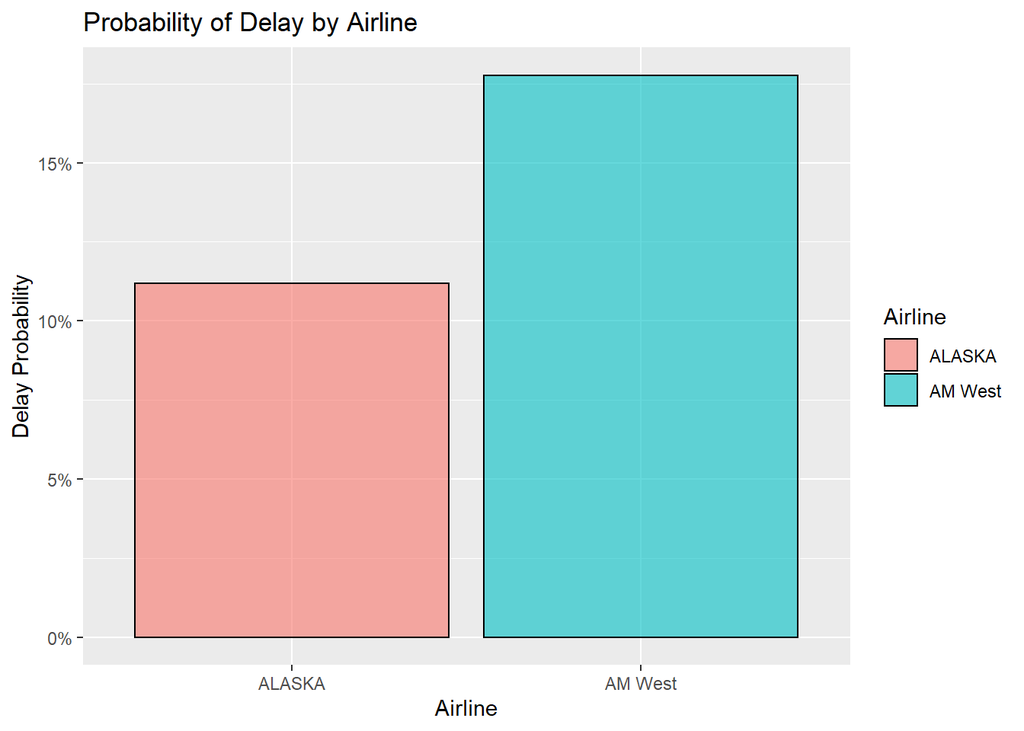

```r
airline.info.long%>% filter(Arrival_Status == "delayed")%>%
    ggplot(aes(y = Occurance_Probability, x = Airline))+
    stat_summary(geom = "bar", fun.y = "mean",alpha = 0.6, aes(fill = Airline), color = "black")+
    labs(title = "Probability of Delay by Airline",
        y = "Delay Probability")+
    scale_y_continuous(labels = scales::percent_format(accuracy = 1))
```

Finally, we can break this out by city and assess the probabilities of a delay by city to see if there are any particular cities that may be skewing delay probabilities.

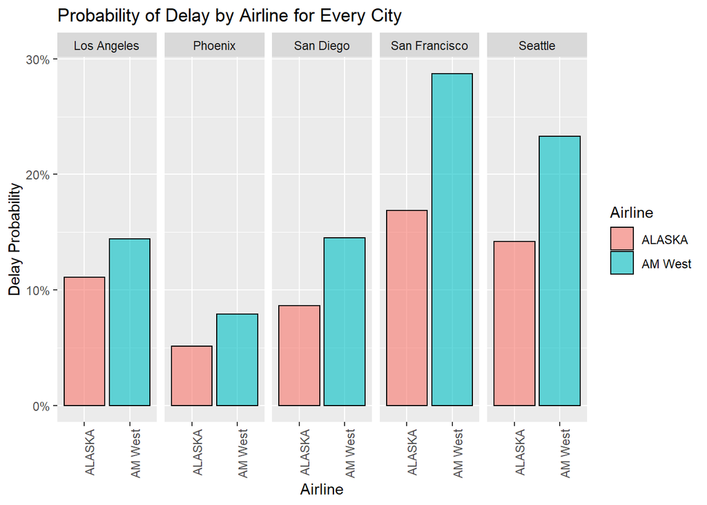

```r
airline.info.long%>% filter(Arrival_Status == "delayed")%>%
    ggplot(aes(y = Occurance_Probability, x = Airline))+
    stat_summary(geom = "bar", fun.y = "mean",alpha = 0.6, aes(fill = Airline), color = "black")+
    labs(title = "Probability of Delay by Airline for Every City",
         y = "Delay Probability")+facet_grid(~City)+
    scale_y_continuous(labels = scales::percent_format(accuracy = 1))+
  theme(axis.text.x =element_text(angle = 90, hjust = 1))
```